# Predicting UFO Sightings

Below, we plot the residuals against both our predictors.

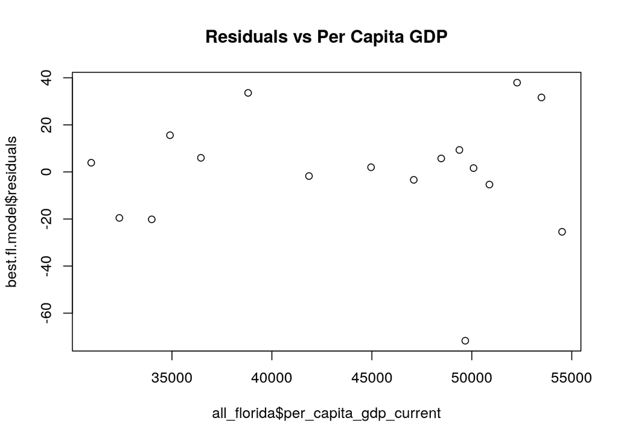

```r
plot(all_florida$per_capita_gdp_current,best.fl.model$residuals, main = "Residuals vs Per Capita GDP")
```

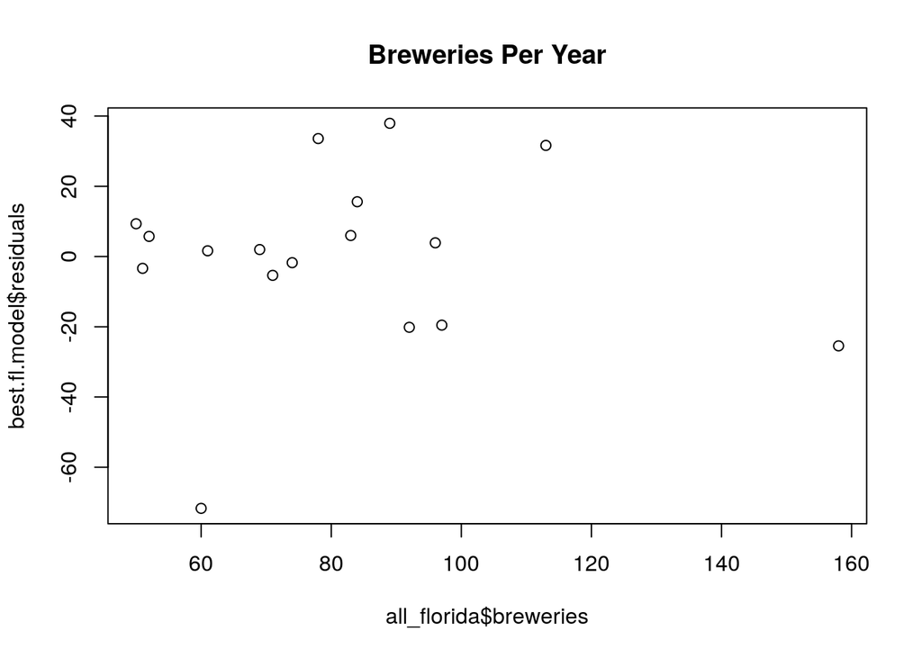

```r
plot(all_florida$breweries, best.fl.model$residuals, main = "Breweries Per Year")
```

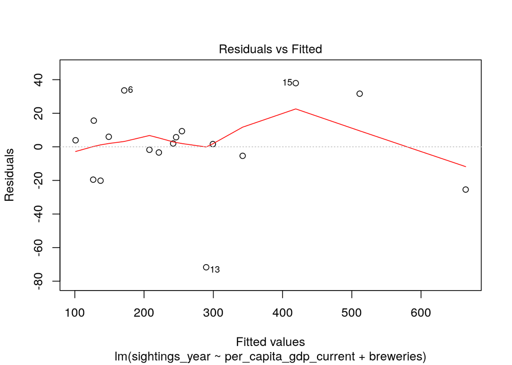

```r
plot(best.fl.model, which = 1)
```

The residuals vs the fitted values show that we have a few definite outliers at point 6, 13, and 15.

## Heteroskedasticity

```r
library(olsrr)
ols_bp_test(best.fl.model)
```

```
##
##  Breusch Pagan Test for Heteroskedasticity
##  -----------------------------------------
##  Ho: the variance is constant
##  Ha: the variance is not constant
##
##                    Data
##  ------------------------------------------
##  Response : sightings_year
##  Variables: fitted values of sightings_year
##
##         Test Summary
##  ----------------------------
##  DF            =    1
##  Chi2          =    1.277793
##  Prob > Chi2   =    0.2583098
```

The test for Breusch Pagan test fails to reject the null hyptothesis that our variance is constant, suggesting we don’t have heteroskedasticity in our model. While the formal mechanical method fails to catch it, our plots suggest there may be non-constant variance in our model.

# Conclusion

## Results

It is likely that the true value we are measuring is population. A greater number of breweries is most likely capturing the actual value of interest, which is the population of the state. A state with a higher population is more likely to more breweries. This does not necessarily capture the “amount of alchohol consumed per capita” that we were interested in capturing.

Still, understanding we may not have created a model allowing for statistical inference, we still have some predictive power.

## Future Work

### Implementing Advanced Spatial-Temporal & Time-Series Models

With the limited scope of our understanding of statistics, we are unable to compare all five explanatory factors with the predicted variable, sightings per year. As we learn more advanced statistical techniques, we can come back to this analysis and improve on modelling with spatial and time dependencies.

### Greater Sample Size

The number of sightings was healthy, over 80,000 reports filed. However, the other data was highly constricted in the amount of years it contained, some having as few as 15 observations. This is insufficient to create the kind of robust model that would be effective for all 50 states.

### Investigate Other States

Here, we identified 5 states that were “super states” in their number of sightings as identified as the density of sightings per state. It may be the case that the number of sightings in these super states and lesser states are fundamentally different, requiring a different model. Or, the “super state” identification may actually be a variable that needs to be considered with a dummy variable to change the intercept for as oppossed to “regular” states.

### Investigate Most Popular Alien Movies

Instead of using alien movies per year, we might use the amount of money grossed in aliens films per year. This would give a greater indicator of a film’s affect on the popular consciousness. A movie like “Aliens” surely had a greater effect than “Mars Needs Moms”, for example. Our current scraping of the data, relying on each movie as a equally effective unit and simply counting the number of movies per year is likely missing a lot of that information.

# Works Cited/ Data Sources

- Open Data Network. 2012. [Data and codebook] (https://www.opendatanetwork.com/dataset/data.hawaii.gov/qnar-gix3)
- National UFO Reporting Center. 2017.[Website data] (http://www.nuforc.org/webreports.html)
- Wikipedia. 2017 [Website data] (https://en.wikipedia.org/wiki/List_of_films_featuring_extraterrestrials)